# Manipulating Network Data

Nic Fox

14/05/2021

The code in this notebook is based on exercises in the book [“Statistical Analysis of Network Data with R” by Kolaczyk and Csardi](https://www.springer.com/gp/book/9781493909834). The authors provide all the [code for their book on Github](https://github.com/kolaczyk/sand).

# 2.2.1 Undirected & Directed Graphs

Terminology:

- **vertices** = nodes
- **edges** = links
- number of vertices (nodes) is called the ‘**order**’ of the graph
- number of edges (links) is called the ‘**size**’ of the graph
- 2 graphs that have the same structure and only differ in the naing of their vertices and edges are called **isomorphic**

Graphs can be **undirected** or **directed**.

A popular R package for working with network data is **igraph**.

```r
knitr::opts_chunk$set(echo = TRUE)
#install.packages("sand")  # created by the book authors & contains datasets used in the exercises
library(igraph)
```

## Create a graph

```r
# create the graph object
g <- graph_from_literal(1-2, 1-3, 2-3, 2-4, 3-5, 4-5, 4-6, 4-7, 5-6, 6-7)

# view the graph object details
g
```

```
## IGRAPH 0c66e1b UN-- 7 10 --
## + attr: name (v/c)
## + edges from 0c66e1b (vertex names):
##  [1] 1--2 1--3 2--3 2--4 3--5 4--5 4--6 4--7 5--6 6--7
```

## Visualise the graph

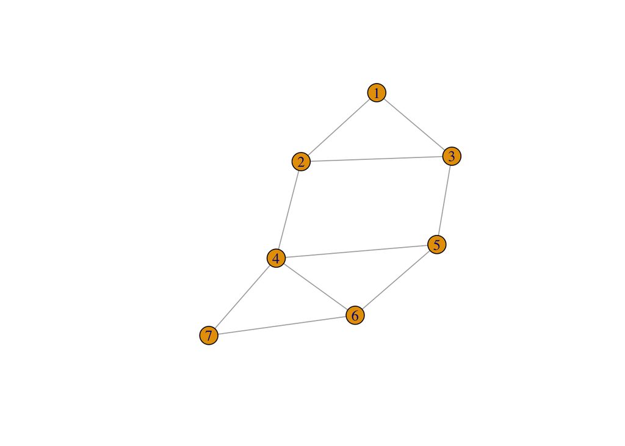

```r
# visualise the graph
plot(g)
```

```r
V(g)
```

```
## + 7/7 vertices, named, from 0c66e1b:
## [1] 1 2 3 4 5 6 7
```

```r
E(g)
```

```
## + 10/10 edges from 0c66e1b (vertex names):
##  [1] 1--2 1--3 2--3 2--4 3--5 4--5 4--6 4--7 5--6 6--7
```

```r
print_all(g)
```

```
## IGRAPH 0c66e1b UN-- 7 10 --
## + attr: name (v/c)
## + edges (vertex names):
## 1 -- 2, 3
## 2 -- 1, 3, 4
## 3 -- 1, 2, 5
## 4 -- 2, 5, 6, 7
## 5 -- 3, 4, 6
## 6 -- 4, 5, 7
## 7 -- 4, 6
```

The **U** in the summary above indicates that the graph is **undirected**.

A **directed graph** is also called a **digraph** and edges in those types of graphs are called **directed edges** or **arcs**. Sometimes there may be 2 arcs between 2 vertices, each going in the opposite direction to the other, and these are called **mutual**.

```r
# create the directed graph with 3 vertices and 4 edges (2 directed and one mutual)
dg <- graph_from_literal(1-+2, 1-+3, 2++3)

# view the information for the directed graph
dg
```

```
## IGRAPH 55f8c7b DN-- 3 4 --
## + attr: name (v/c)
## + edges from 55f8c7b (vertex names):
## [1] 1->2 1->3 2->3 3->2
```

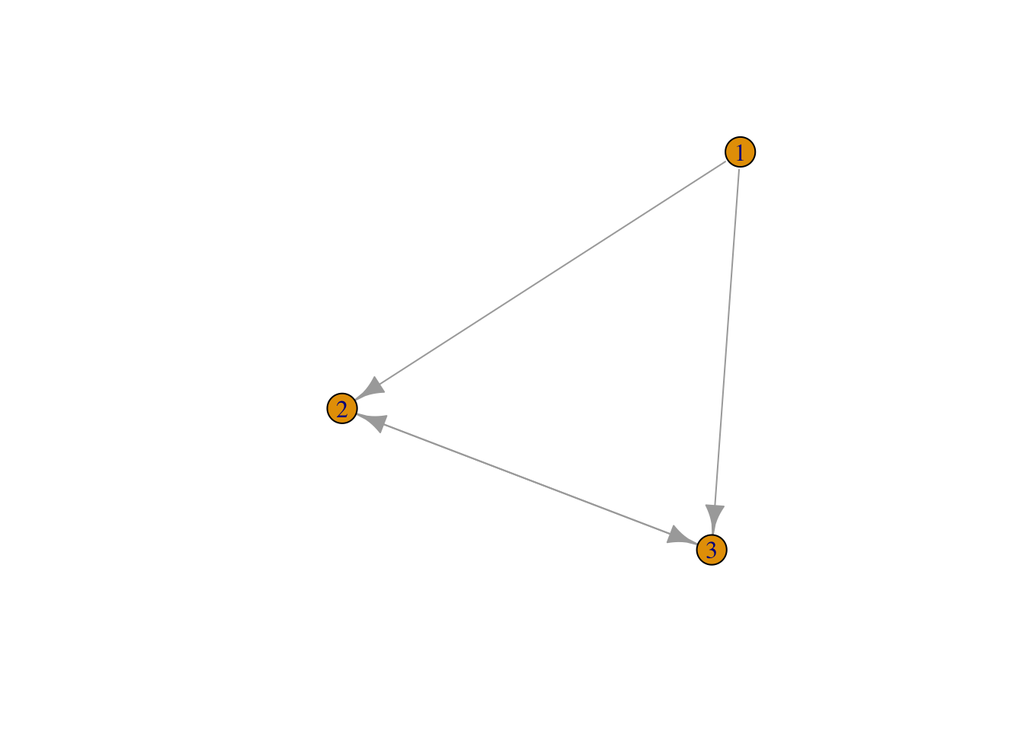

```r
plot(dg)
```

```r
dg_names <- graph_from_literal(Sam-+Mary, Sam-+Tom, Mary++Tom)
print_all(dg_names)
```

```
## IGRAPH 1d216f7 DN-- 3 4 --
## + attr: name (v/c)
## + edges from 1d216f7 (vertex names):
## [1] Sam ->Mary Sam ->Tom  Mary->Tom  Tom ->Mary
```

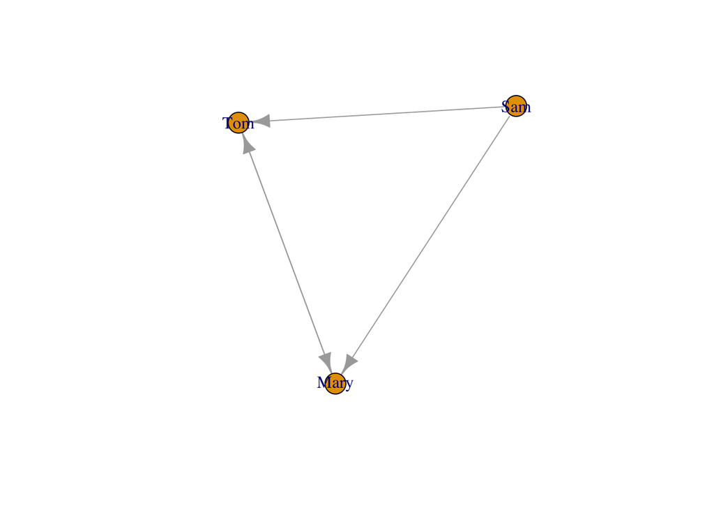

```r
plot(dg_names)
```

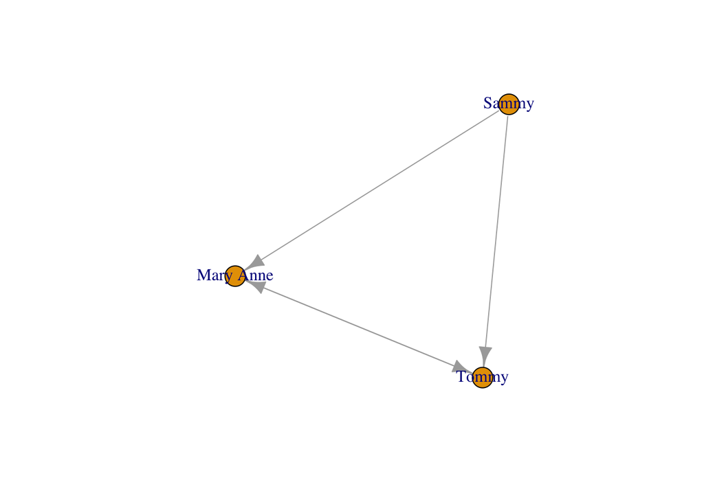

```r
V(dg_names)$name <- c("Sammy", "Mary Anne", "Tommy")
plot(dg_names)
```

# 2.2.2 Representations for Graphs

- adjacency list
- edge list
- adjacency matrix

## Adjacency list

Example: the list of nodes and list of directly associated nodes for each of those nodes, as seen in the output for `print_all()`

```r
print_all(g)
```

```
## IGRAPH 0c66e1b UN-- 7 10 --
## + attr: name (v/c)
## + edges (vertex names):
## 1 -- 2, 3
## 2 -- 1, 3, 4
## 3 -- 1, 2, 5
## 4 -- 2, 5, 6, 7
## 5 -- 3, 4, 6
## 6 -- 4, 5, 7
## 7 -- 4, 6
```

## Edge list

A 2-column list of vertex pairs that are joined by an edge.

```r
as_edgelist(g)
```

```
##       [,1] [,2]
##  [1,] "1"  "2"
##  [2,] "1"  "3"
##  [3,] "2"  "3"
##  [4,] "2"  "4"
##  [5,] "3"  "5"
##  [6,] "4"  "5"
##  [7,] "4"  "6"
##  [8,] "4"  "7"
##  [9,] "5"  "6"
## [10,] "6"  "7"
```

## Adjacency matrix

```r
as_adjacency_matrix(g)
```

```
## 7 x 7 sparse Matrix of class "dgCMatrix"
##   1 2 3 4 5 6 7
## 1 . 1 1 . . . .
## 2 1 . 1 1 . . .
## 3 1 1 . . 1 . .
## 4 . 1 . . 1 1 1
## 5 . . 1 1 . 1 .
## 6 . . . 1 1 . 1
## 7 . . . 1 . 1 .
```

## Useful functions

- `graph_from_adj_list()`
- `graph_from_edge_list()`
- `graph_from_adjacency_matrix()`
- `read_graph()` - for data stored in a file
- `write_graph()` - to save graph data to a file